# Web App for Processing NHANES Accelerometer Data

Dane Van Domelen

January 14, 2019

### Background (skippable)

Although it was released over 10 years ago, the accelerometer data from NHANES 2003-2004 and 2005-2006 is likely still the richest existing dataset with objectively measured physical activity in a representative sample of Americans. There is still plenty that could be done with these data. Plus, mortality data is still coming in, and might keep coming in for the next 75+ years! So the dataset remains highly relevant.

Upon initial release, the National Cancer Institute provided SAS files with the raw minute-to-minute accelerometer data, along with SAS scripts for processing the data (https://epi.grants.cancer.gov/nhanes_pam/). The NCI deserves a lot of credit for publishing these scripts. However, they have some limitations:

- Users have to download 3.87 GB data files to their computer.
- Users must have a SAS license.
- The scripts only calculate a few basic physical activity variables.
- The SAS scripts are slow (e.g. 25 minutes to process just the 2003-2004 data!).

As a result, many research groups wrote their own scripts to process the data according to their own preferences. I did this for a while, and then decided to write an R package to share my functions with other researchers.

Briefly, I developed the R package **accelerometry** (D. R. Van Domelen 2018) to provide general-purpose functions for various steps: removing non-wear time, identifying activity bouts, and so forth. I used C++ via the **Rcpp** package (Eddelbuettel and Francois 2018, Eddelbuettel and François (2011), Eddelbuettel (2013), Eddelbuettel and Balamuta (2017)) to make the functions fast. Then, I developed **nhanesaccel** to process the NHANES data specifically. Its main function, *process_nhanes*, which has many arguments that users can specify to process the data according to their own personal preferences. More details on the implementation are available (D. Van Domelen and Pittard 2014).

## The app

Most physical activity researchers are in fact *not* R users, so it occurred to me that my functions would be much more useful if they could be accessed through a web app. So, I created one using R Shiny (Chang et al. 2018). It is available here:

https://jhubiostatistics.shinyapps.io/process_nhanes_app/

Basically, the app provides a user interface for the *process_nhanes* function. The main benefit is that it allows researchers to fully process the NHANES data, and export a file for analysis in R, SAS, Stata, or SPSS, without any specialized software. All you need is an internet connection.

Here’s a screen grab of the starting screen:

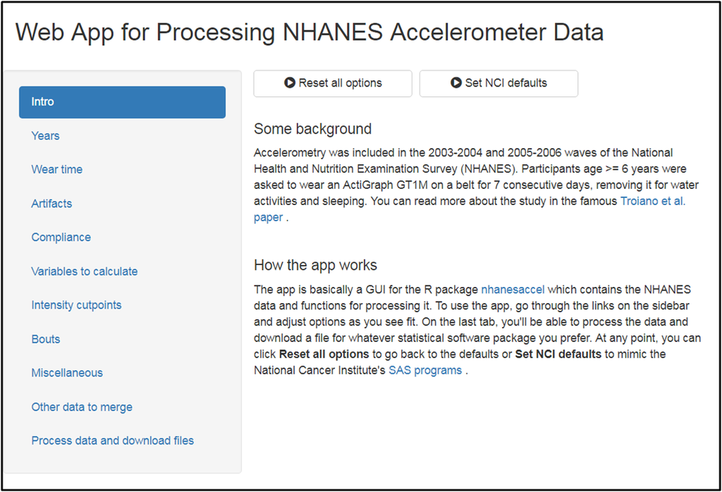

You can go through the sidebar links and select your preferred options…

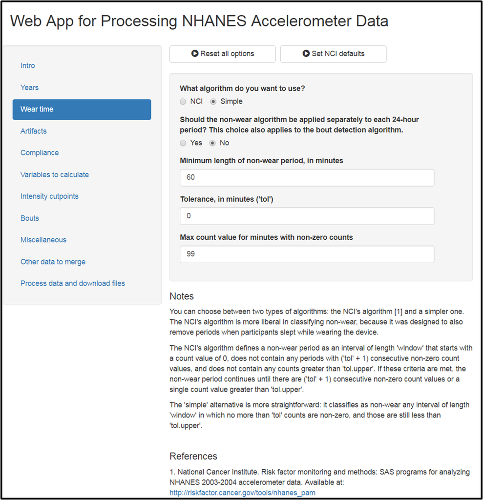

On the last screen, clicking ‘Process Data’ will result in an underlying R session processing the data according to your preferences. And when data processing is complete, you’ll be able to download analysis files for R, SAS, Stata, or SPSS.

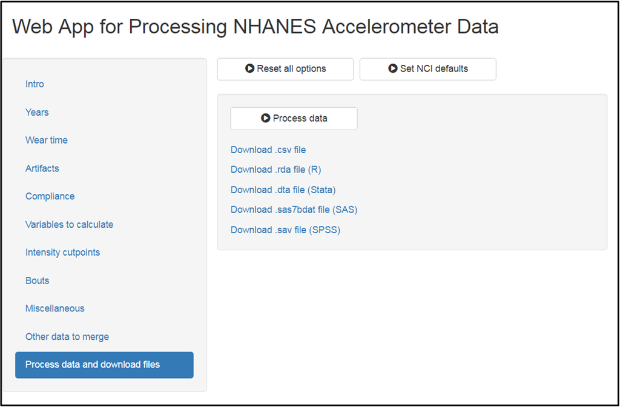

### Bugs etc.

If you find any bugs in the app, or have questions on how to use it or suggestions for how to improve it, please do not hesitate to e-mail me at vandomed@gmail.com. Thanks!

### References

Chang, Winston, Joe Cheng, JJ Allaire, Yihui Xie, and Jonathan McPherson. 2018. *Shiny: Web Application Framework for R*. https://CRAN.R-project.org/package=shiny.

Eddelbuettel, Dirk. 2013. *Seamless R and C++ Integration with Rcpp*. New York: Springer. doi:10.1007/978-1-4614-6868-4.

Eddelbuettel, Dirk, and James Joseph Balamuta. 2017. “Extending R with C++: A Brief Introduction to Rcpp.” *PeerJ Preprints* 5 (August): e3188v1. doi:10.7287/peerj.preprints.3188v1.

Eddelbuettel, Dirk, and Romain Francois. 2018. *Rcpp: R / C++ Interface*.

Eddelbuettel, Dirk, and Romain François. 2011. “Rcpp: Seamless R and C++ Integration.” *Journal of Statistical Software* 40 (8): 1–18. doi:10.18637/jss.v040.i08.

Van Domelen, Dane R. 2018. *Accelerometry: Functions for Processing Accelerometer Data*.

Van Domelen, Dane, and W. Stephen Pittard. 2014. “Flexible R Functions for Processing Accelerometer Data, with Emphasis on Nhanes 2003-2006.” *The R Journal* 6 (2). https://journal.r-project.org/archive/2014/RJ-2014-024/RJ-2014-024.pdf.